# Crecimiento Económico. Política Fiscal y Crecimiento

### Gobierno y nivel del PIB per cápita

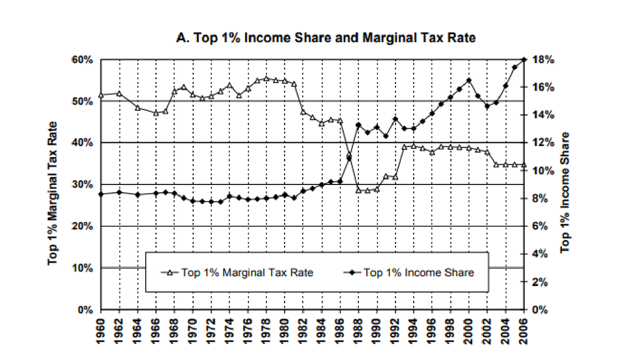

### Impuestos y crecimiento

- El mismo análisis se ve en los datos de impuestos de la Reserva Federal de Estados Unidos.
- El patrón es que esta tasa marginal máxima disminuye con el tiempo, con algunas oscilaciones, tomando como máximo el 90% en la década de 1950 y el mínimo de 30% en 1990.
- [**Tasa imposotiva y crecimiento**](https://fred.stlouisfed.org/graph/graph-landing.php?g=FOJf&width=1000&height=475)
- Gale y Samwick analizan el efecto de dos tipos de cambios en los impuestos al ingreso: cambios a las tasas, y reformas que aumentan la base tributaria y reducen las tasas de impuestos.
- La evidencia histórica de Estados Unidos muestra grandes cambios en los impuestos con prácticamente ningún cambio observable en las tasas de crecimiento.

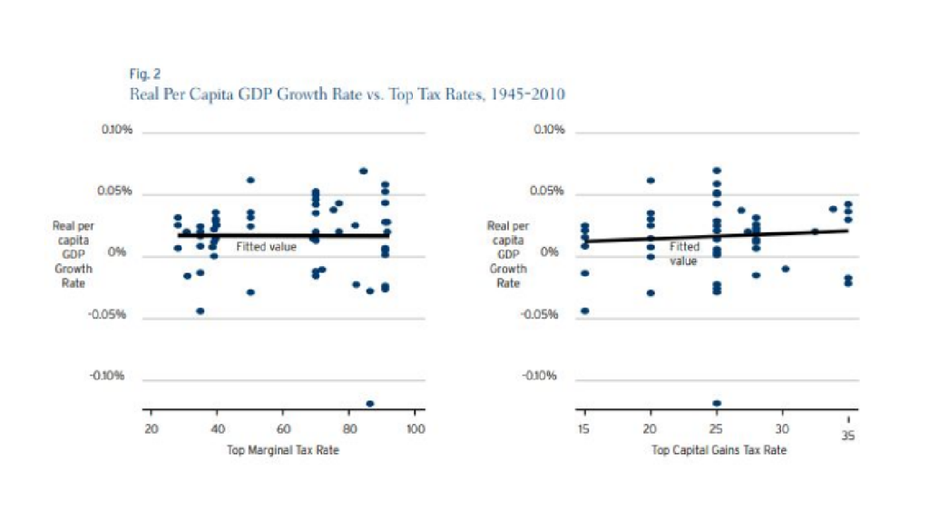

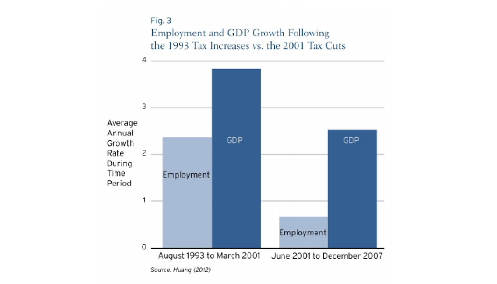

- Yagan estudió el efecto de este recorte de 2003. Con un recorte en la tasa de impuestos a los dividendos, podríamos esperar que las corporaciones C (que pagan dividendos) incrementaran su gasto de inversión en relación con las corporaciones S (que no los pagan) pero no encontró ningún efecto en sus gastos de inversión.

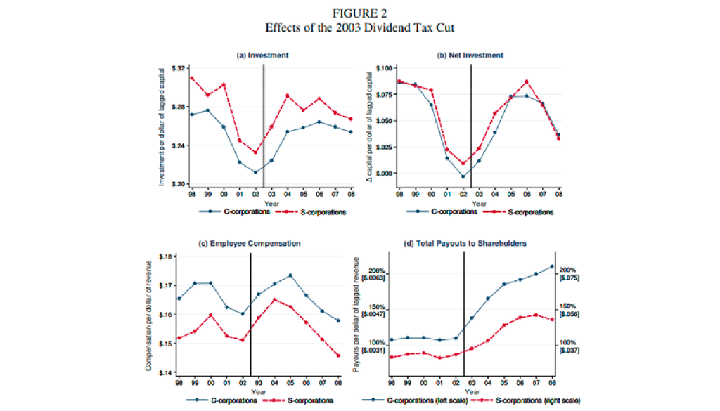

- Ufuk, Akcigit, Grigsby, Nicholas y Stantcheva examinaron el efecto de los impuestos corporativos y personales sobre la innovación en Estados Unidos. Descubrieron que existen efectos significativos de las tasas impositivas (cambios en el top 10) sobre la ubicación y la cantidad de actividad innovadora, medida por patentes, en todos los Estados.
- Las corporaciones, en particular, parecen mover su actividad innovadora de un estado a otro en respuesta a las tasas impositivas. Los efectos son más débiles cuando hay efectos de aglomeración en la innovación

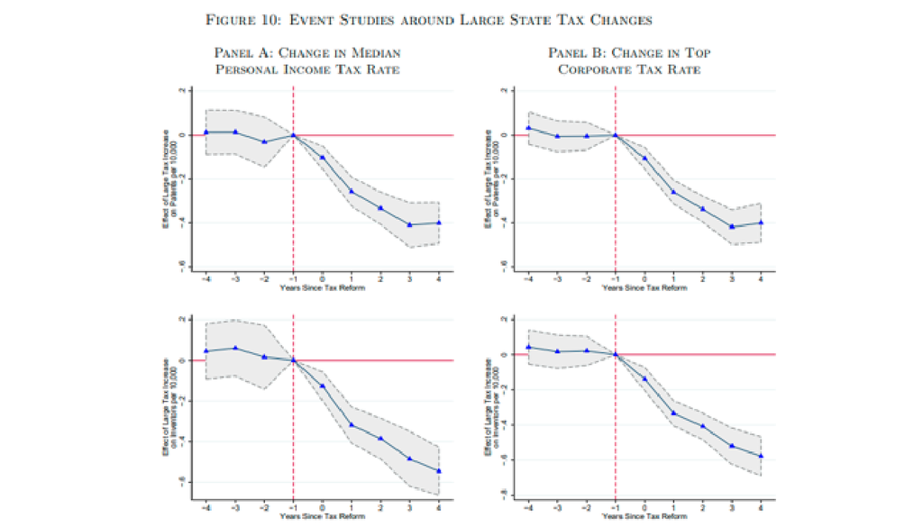

### Impuestos y oferta laboral

- Otra afectación puede ser vía el mercado laboral: esperaríamos que a medida que las tasas del impuesto sobre la renta de las personas físicas disminuyan, los trabajadores estarán más dispuestos a proporcionar trabajo.
- Al aplicar el recorte impositivo, el top 1% aumenta sus porcentajes de ingreso. Sin embargo, el top 9% siguiente no modifica sus porcentajes de ingreso ni en los aumentos ni en los recortes impositivos.

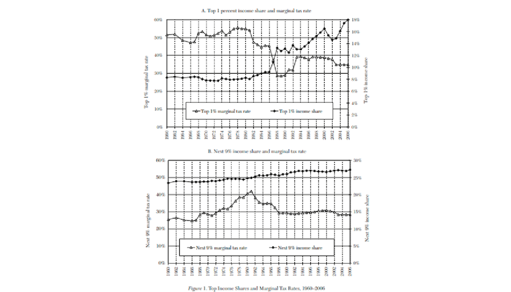

- Una reducción en la tasa impositiva puede lograr crecimiento en el empleo, pero solo si se hace a los hogares de medianos y bajos ingresos. Esto se debe a 2 razones:
1. La oferta laboral de los hogares de altos ingresos no se ve modificada por las tasas impositivas, mientras que si afecta la de los hogares de mediano y bajo ingreso.
2. Los ricos ahorrarían el recorte de impuestos, mientras que los siguientes estratos lo gastan.

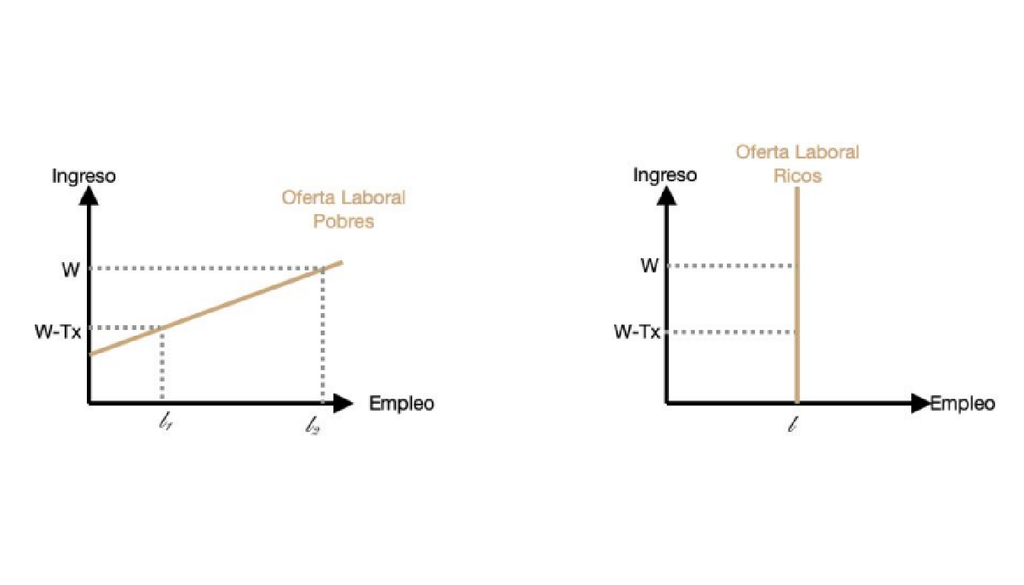

- Si lo que se busca es impulsar la economía con recortes a los impuestos, es más probable que esto se de si los recortes se hacen a las personas de medios y bajos ingresos.